Skip to main content

# Diagnostics and model choice

- Show All Code
- Hide All Code
- View Source

Does the gamma model with log link describe the data, and would another model change the result?

**Code: setup, and checks that the statements of the text hold in the data**

```r
source("_common.R")
dg <- tab("tableS_diagnostics"); d <- setNames(dg$value, dg$quantity)
di <- tab("tableS_diagnostics_initial"); d0 <- setNames(di$value, di$quantity)
mc <- tab("tableS_model_comparison"); af <- rows(R$alternative_families); vf <- R$variance_function
fm <- tab("tableS_fit_measures")
NL <- rows(R$nonlinearity)
gam <- mc[grepl("^Gamma", mc$model), ]
# statements made in the text must hold in the data
stopifnot(min(mc$delta_aic[grepl("^Gaussian", mc$model)]) - max(gam$delta_aic) > 100, gam$delta_aic[grepl("log link", gam$model)] == 0,
          vf$lcl < 2, vf$ucl > 2, vf$p_gaussian < 0.05, all(af$delta_aic_vs_primary[2:3] < 0),
          max(abs(af$pct_difference - af$pct_difference[1])) < 0.1,
          as.numeric(d[["Link test P (squared linear predictor)"]]) > 0.05, as.numeric(d0[["Link test P (squared linear predictor)"]]) < 0.05,
          PR$max_cook < 0.5, SUB$max_cook > 1, NL$p_nonlinearity[1] > 0.05, d[["Term with largest adjusted GVIF"]] == "waist_cm")
```

## Short answer

The gamma model with log link is an adequate and defensible choice for these data, and the result does not depend on it.

- Gamma models fit better than Gaussian models (difference in AIC above 100), and the log link has the lowest AIC of the three gamma link functions.
- The variance function estimated from the residuals is compatible with the gamma and inverse Gaussian models: the power estimated by the modified Park test is 2.4 (95% CI 1.1 to 3.7), where 2 corresponds to the gamma model. The interval is wide.
- Inverse Gaussian and log-normal models fit somewhat better by AIC and give similar estimates for SHBG (−0.45% and −0.42% per doubling, against −0.40% in the primary model).
- What changes the estimate is not the distribution but one covariate, waist circumference. See Sensitivity analyses.

## Fit and residuals

```r
dv <- function(x, m) c(as.character(S$n - as.numeric(x[["Residual df"]])), x[["Dispersion parameter"]],
                    paste0(x[["Residual deviance"]], " (", fmt(as.numeric(x[["Residual df"]]), 0), ")"),
                    fmt(100 * as.numeric(x[["Deviance explained (1 - deviance/null deviance)"]]), 1), fmt(fm$aic[fm$model == m], 1),
                    x[["RMSE, kg"]], x[["Correlation observed vs fitted"]],
                    fmt(as.numeric(x[["Largest Cook's distance"]]), 2), fmt(as.numeric(x[["Largest leverage"]]), 2),
                    x[["Observations with Cook's distance > 4/n"]],
                    paste0(x[["Largest adjusted GVIF"]], " (", x[["Term with largest adjusted GVIF"]], ")"), x[["Link test P (squared linear predictor)"]])
kt(data.frame(Quantity = c("Coefficients estimated", "Dispersion parameter", "Residual deviance (residual degrees of freedom)", "Deviance explained, %", "AIC",
                           "Root mean squared error, kg", "Correlation between observed and fitted values", "Largest Cook's distance", "Largest leverage",
                           "Observations with Cook's distance above 4/n", "Largest adjusted generalized variance inflation factor", "Link test, P value"),
              `Primary model` = dv(d, "Primary model"), `Initial model` = dv(d0, "Initial model"), check.names = FALSE), align = "lrr")
```

| Quantity | Primary model | Initial model |
| --- | --- | --- |
| Coefficients estimated | 22 | 18 |
| Dispersion parameter | 0.01131 | 0.02097 |
| Residual deviance (residual degrees of freedom) | 17.913 (1,671) | 33.875 (1,675) |
| Deviance explained, % | 55.8 | 16.5 |
| AIC | 7,309.8 | 8,383.2 |
| Root mean squared error, kg | 2.176 | 2.956 |
| Correlation between observed and fitted values | 0.737 | 0.397 |
| Largest Cook’s distance | 0.09 | 6.11 |
| Largest leverage | 0.21 | 0.77 |
| Observations with Cook’s distance above 4/n | 69 | 80 |
| Largest adjusted generalized variance inflation factor | 2.08 (waist_cm) | 1.41 (estradiol) |
| Link test, P value | 0.923 | 0.026 |

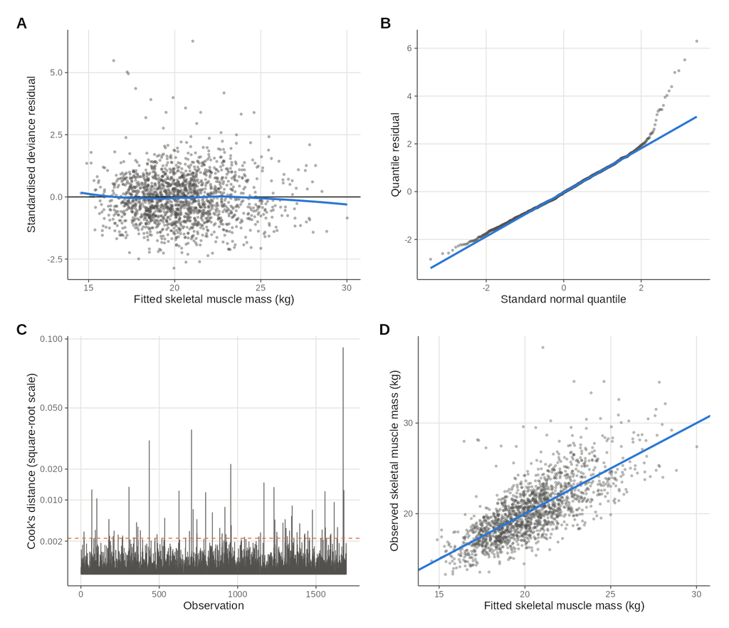

Diagnostic plots of the primary model. (A) Standardized deviance residuals against fitted values. (B) Normal quantile plot of the quantile residuals. (C) Cook’s distance by observation. (D) Observed against fitted skeletal muscle mass.

In the primary model, quantile residuals are close to the normal distribution except in the upper tail, and the deviance residuals show no trend with the fitted values. Collinearity is not a concern. The link test gives no evidence that the linear predictor is misspecified, and there is no evidence of departure from linearity for log2(SHBG) (P = 0.106). No single observation has a large influence; the estimate without the 69 observations with a Cook’s distance above 4/n is on the page Sensitivity analyses.

**NoteVariance inflation factors by term (primary model)**

```r
vif <- tab("tableS_vif")
kt(data.frame(Term = vif$term, `Adjusted generalized variance inflation factor` = fmt(vif$adjusted_gvif, 2), check.names = FALSE), align = "lr")
```

| Term | Adjusted generalized variance inflation factor |
| --- | --- |
| log2(shbg) | 1.38 |
| log2(testosterone) | 1.36 |
| log2(fsh) | 1.89 |
| log2(estradiol) | 1.72 |
| log2(tsh) | 1.06 |
| log2(dheas) | 1.36 |
| age | 1.21 |
| height_cm | 1.22 |
| waist_cm | 2.08 |
| race | 1.19 |
| status | 1.09 |
| activity_limit | 1.07 |
| exercise | 1.07 |

## Distribution and link function

```r
kt(data.frame(Model = mc$model, AIC = fmt(mc$aic, 1), `Difference in AIC` = fmt(mc$delta_aic, 1), `RMSE, kg` = fmt(mc$rmse_kg, 3),
              `Difference in muscle mass per doubling of SHBG, kg` = fmt(mc$change_smm_kg_per_doubling, 2), `P value for SHBG` = pval(mc$shbg_p),
              check.names = FALSE), align = "lrrrrr")
```

| Model | AIC | Difference in AIC | RMSE, kg | Difference in muscle mass per doubling of SHBG, kg | P value for SHBG |
| --- | --- | --- | --- | --- | --- |
| Gamma, log link (primary) | 7,309.8 | 0.0 | 2.176 | −0.08 | 0.223 |
| Gamma, identity link | 7,322.2 | 12.4 | 2.183 | −0.07 | 0.322 |
| Gamma, inverse link | 7,323.8 | 14.0 | 2.188 | −0.09 | 0.163 |
| Gaussian, log link | 7,481.6 | 171.8 | 2.175 | −0.06 | 0.371 |
| Gaussian, identity link | 7,490.8 | 181.0 | 2.181 | −0.05 | 0.455 |
| Gaussian, inverse link | 7,497.7 | 187.9 | 2.185 | −0.07 | 0.312 |

Same sample and linear predictor (log2 SHBG and the covariates of the primary model) in every model, ordered by AIC. The difference in kilograms is the average change in the model predictions for a doubling of SHBG, which places all link functions on the same scale. Among the gamma models the log link has the lowest AIC (the identity and inverse links are 12.4 and 14.0 units higher), and every model gives a difference between −0.05 and −0.09 kg. With the log link the coefficients are ratios of means.

## Other families with a log-scale mean

```r
kt(data.frame(Model = af$model, `Variance` = gsub("^3", "³", gsub("^2", "²", af$variance_function, fixed = TRUE), fixed = TRUE), Estimand = af$estimand, AIC = fmt(af$aic, 1),
              `Difference in AIC vs primary` = fmt(af$delta_aic_vs_primary, 1),
              `Difference per doubling of SHBG, % (95% CI)` = paste0(fmt(af$pct_difference, 2), " (", ci(af$pct_lcl, af$pct_ucl), ")"),
              `Difference, kg` = fmt(af$change_smm_kg_per_doubling, 2), check.names = FALSE), align = "lllrrrr")
```

| Model | Variance | Estimand | AIC | Difference in AIC vs primary | Difference per doubling of SHBG, % (95% CI) | Difference, kg |
| --- | --- | --- | --- | --- | --- | --- |
| Gamma, log link (primary) | proportional to mean² | ratio of arithmetic means | 7,309.8 | 0.0 | −0.40 (−1.05 to 0.25) | −0.08 |
| Inverse Gaussian, log link | proportional to mean³ | ratio of arithmetic means | 7,271.2 | −38.6 | −0.45 (−1.10 to 0.21) | −0.09 |
| Log-normal (linear regression of log muscle mass) | proportional to mean² (constant on the log scale) | ratio of geometric means | 7,271.8 | −38.0 | −0.42 (−1.05 to 0.21) | −0.09 |

AIC values are on the scale of skeletal muscle mass. Both alternatives have a lower AIC than the gamma model, and the estimates for SHBG differ from it by less than 0.1 percentage points. Skeletal muscle mass has a small coefficient of variation (16%), so these distributions are close to each other over the range of the data.

## Variance function

```r
kt(data.frame(Quantity = c("Power of the variance function, λ", "95% confidence interval", "P value for λ = 2 (gamma)",
                           "P value for λ = 0 (Gaussian)", "P value for λ = 3 (inverse Gaussian)"),
              Value = c(fmt(vf$lambda, 2), ci(vf$lcl, vf$ucl, 2), pval(vf$p_gamma), pval(vf$p_gaussian), pval(vf$p_inverse_gaussian))), align = "lr")
```

| Quantity | Value |
| --- | --- |
| Power of the variance function, λ | 2.39 |
| 95% confidence interval | 1.08 to 3.69 |
| P value for λ = 2 (gamma) | 0.563 |
| P value for λ = 0 (Gaussian) | <0.001 |
| P value for λ = 3 (inverse Gaussian) | 0.356 |

Modified Park test (definition) with a robust standard error. The estimate is imprecise because skeletal muscle mass varies over a narrow range. It is compatible with the gamma and inverse Gaussian variance functions and not with a constant variance.

## What would change the result

| Decision | Effect on the estimate for SHBG |
| --- | --- |
| Distribution (gamma, inverse Gaussian, log-normal, Gaussian) | none of practical size |
| Link function (log, identity, inverse) | none of practical size |
| Robust standard errors | none |
| Functional form of SHBG in the primary model (logarithm, linear, spline) | none of practical size |
| Removing any covariate other than waist circumference | none of practical size |
| Body mass index or weight instead of waist circumference | none of practical size |
| Scaling of muscle mass (index, percentage of body weight) | none of practical size |
| Removing waist circumference, or using fat mass or percent body fat from impedance as the only measure of adiposity | large: an inverse association appears |

## Code behind this page

The code of each table is folded above it (*Code*), and the *Code* menu at the top of the page shows or hides all of it. That code only reads the output of the pipeline. The numbers are computed by the scripts below, shown as they are in [`analysis/`](https://github.com/AmaruSimonAgueroJimenez/SWAN/tree/main/analysis) and not run here. All the scripts of the pipeline are on the page Reproducibility.

**analysis/config.R · paths, reporting units, reference categories, expected values of the models**

```r
# =============================================================================
# Configuration for the SHBG / skeletal muscle mass analysis (PLOS ONE revision)
# Single source of truth for paths, units and analysis settings.
# All scripts are run from the repository root (see analysis/run_all.R).
# =============================================================================

CFG <- list(
  # ---- paths ---------------------------------------------------------------
  data_file = file.path("ICPSR_32961", "DS0001", "32961-0001-Data.dta"),
  out_dir   = file.path("analysis", "output"),

  # ---- inference -----------------------------------------------------------
  conf_level = 0.95,
  seed       = 20261117L,   # only used for the randomised quantile residuals

  # ---- reporting units -----------------------------------------------------
  # Associations are reported as ratios of means per `unit` of each covariate.
  unit = c(
    shbg         = 10,   # nmol/L
    testosterone = 10,   # ng/dL
    fsh          = 10,   # mIU/mL
    estradiol    = 10,   # pg/mL
    tsh          = 1,    # uIU/mL
    dheas        = 50,   # ug/dL
    age          = 1,    # years
    pbf          = 5,    # percentage points
    bmi          = 1,    # kg/m2
    height_cm    = 5,    # cm
    weight_kg    = 5,    # kg
    fat_mass_kg  = 5,    # kg
    waist_cm     = 5,    # cm
    smm          = 1     # kg (used when SHBG is the dependent variable)
  ),

  # ---- SI conversion (dataset unit x factor = SI unit) ------------------------
  # Factors follow from the molar masses (4 significant digits): testosterone 288.42 g/mol,
  # estradiol 272.38 g/mol, DHEA-S 368.49 g/mol. FSH (mIU/mL = IU/L) and
  # TSH (uIU/mL = mIU/L) are numerically identical in SI units.
  si = list(
    testosterone = list(factor = 0.03467, unit = "nmol/L", digits = 2L),
    estradiol    = list(factor = 3.671,  unit = "pmol/L", digits = 1L),
    dheas        = list(factor = 0.02714, unit = "umol/L", digits = 2L)
  ),

  # ---- reference categories --------------------------------------------------
  ref_status   = "Natural post-menopause",
  ref_activity = "Not limited",
  ref_exercise = "No",
  ref_race     = "White",

  # ---- regression tests -------------------------------------------------------
  # Primary model (revised in November 2026): gamma log-link model of skeletal
  # muscle mass on log2(SHBG), adjusted for age, height, waist circumference,
  # race/ethnicity, menopausal status, log2 hormones, activity limitation and
  # exercise. The pipeline stops if these values are not reproduced.
  expected_primary = list(n = 1693L, aic = 7309.813, beta_log2_shbg = -0.004054),
  # Model of the first submission (SKELMMM10 in docs/exploratory.qmd and
  # docs/resultados_modelos_SKELMMM.xlsx), now a sensitivity analysis.
  expected_submitted = list(n = 1693L, aic = 8383.171, beta_shbg = -0.001069)
)
```

**analysis/R/functions.R · definition of the primary and initial models, model fitting, ratios of means, standardized means**

```r
# =============================================================================
# Helper functions shared by every analysis script
# =============================================================================

suppressPackageStartupMessages({
  library(dplyr)
  library(tidyr)
})

# ---- model fitting ----------------------------------------------------------
# All ratio-scale models go through this single function so that the family and
# link are guaranteed to be identical across the primary and sensitivity models.
fit_gamma_log <- function(formula, data) {
  m <- glm(formula, data = data, family = Gamma(link = "log"))
  stopifnot(m$converged)
  m
}

# Hormone covariates (all strictly positive concentrations).
HORMONES <- c("testosterone", "fsh", "estradiol", "tsh", "dheas")

# Primary model (revised in November 2026). SHBG and the hormone covariates enter
# on the log2 scale; body size is represented by height and waist circumference.
PRIMARY_EXPOSURE   <- "log2(shbg)"
PRIMARY_COVARIATES <- c(paste0("log2(", HORMONES, ")"), "age", "height_cm", "waist_cm", "race",
                        "status", "activity_limit", "exercise")

# Initial model: the model of the first submission (SKELMMM10; only the reference level of
# menopausal status differs, which does not change the fit). Kept as a sensitivity analysis
# and called "initial model" in every table and figure.
SUBMITTED_EXPOSURE   <- "shbg"
SUBMITTED_COVARIATES <- c(HORMONES, "age", "pbf", "status", "activity_limit", "exercise")

# Variables that must be complete for a woman to be analysed: those of the primary
# model and of the submitted model, so that every model uses the same sample.
MODEL_VARIABLES <- c("smm", "shbg", HORMONES, "age", "height_cm", "waist_cm", "race",
                     "status", "activity_limit", "exercise", "pbf")

make_formula <- function(outcome, exposure, covariates) {
  reformulate(c(exposure, covariates), response = outcome)
}

# ---- extraction -------------------------------------------------------------
# Ratio of means (exp(beta * unit)) with a Wald interval based on the
# t distribution with the residual degrees of freedom, i.e. the same reference
# distribution that summary.glm() uses for families with estimated dispersion.
ratio_for_term <- function(model, term, unit, conf_level, vcov_matrix = NULL) {
  stopifnot(term %in% names(coef(model)))
  beta <- unname(coef(model)[term])
  V    <- if (is.null(vcov_matrix)) vcov(model) else vcov_matrix
  se   <- sqrt(V[term, term])
  df   <- model$df.residual
  crit <- qt(1 - (1 - conf_level) / 2, df)
  tval <- beta / se
  data.frame(
    term     = term,
    unit     = unit,
    beta     = beta,
    se       = se,
    ratio    = exp(unit * beta),
    lcl      = exp(unit * (beta - crit * se)),
    ucl      = exp(unit * (beta + crit * se)),
    p        = 2 * pt(abs(tval), df, lower.tail = FALSE),
    n        = nobs(model),
    stringsAsFactors = FALSE
  )
}

# Marginally standardised mean of a log-link model across values of SHBG, with
# delta-method confidence limits. Every participant is assigned SHBG = x and the
# predictions are averaged over the observed covariates:
#   m(x) = mean_i exp(X_i(x) b);   dm/db = mean_i exp(X_i(x) b) X_i(x)
marginal_curve <- function(model, data, grid, conf_level) {
  stopifnot(family(model)$link == "log", "shbg" %in% all.vars(formula(model)))
  tt <- delete.response(terms(model)); V <- vcov(model); b <- coef(model)
  crit <- qt(1 - (1 - conf_level) / 2, model$df.residual)
  do.call(rbind, lapply(grid, function(x) {
    nd <- data; nd$shbg <- x
    X  <- model.matrix(tt, nd, xlev = model$xlevels)
    mu <- as.vector(exp(X %*% b))
    g  <- colMeans(mu * X)
    se <- sqrt(as.numeric(t(g) %*% V %*% g))
    data.frame(shbg = x, mean = mean(mu), lcl = mean(mu) - crit * se, ucl = mean(mu) + crit * se)
  }))
}

# Full regression output on the scale of the linear predictor
full_output <- function(model, label) {
  co <- summary(model)$coefficients
  data.frame(model = label, term = rownames(co), beta = co[, "Estimate"], se = co[, "Std. Error"],
             t = co[, "t value"], p = co[, "Pr(>|t|)"], row.names = NULL, stringsAsFactors = FALSE)
}
fit_measures <- function(model, label) {
  data.frame(model = label, n = nobs(model), residual_df = model$df.residual,
             dispersion = summary(model)$dispersion, null_deviance = model$null.deviance,
             residual_deviance = deviance(model), log_likelihood = as.numeric(logLik(model)),
             aic = AIC(model), bic = BIC(model), stringsAsFactors = FALSE)
}

# percent difference implied by a ratio
pct <- function(ratio) 100 * (ratio - 1)

# ---- formatting -------------------------------------------------------------
fmt_num <- function(x, digits) formatC(x, format = "f", digits = digits, big.mark = ",")

fmt_p <- function(p) {
  ifelse(is.na(p), NA_character_,
         ifelse(p < 0.001, "<0.001", formatC(p, format = "f", digits = 3)))
}

fmt_ci <- function(est, lcl, ucl, digits) {
  sprintf("%s (%s to %s)", fmt_num(est, digits), fmt_num(lcl, digits), fmt_num(ucl, digits))
}

mean_sd <- function(x, digits = 1) {
  stopifnot(!anyNA(x))
  sprintf("%s (%s)", fmt_num(mean(x), digits), fmt_num(sd(x), digits))
}

median_iqr <- function(x, digits = 1) {
  stopifnot(!anyNA(x))
  q <- quantile(x, c(0.25, 0.5, 0.75), names = FALSE)
  sprintf("%s (%s to %s)", fmt_num(q[2], digits), fmt_num(q[1], digits), fmt_num(q[3], digits))
}

n_pct <- function(x, level, digits = 1) {
  stopifnot(!anyNA(x))
  k <- sum(x == level)
  sprintf("%s (%s)", fmt_num(k, 0), fmt_num(100 * k / length(x), digits))
}

# ---- output -----------------------------------------------------------------
write_table <- function(df, name, out_dir) {
  path <- file.path(out_dir, "tables", paste0(name, ".csv"))
  write.csv(df, path, row.names = FALSE, fileEncoding = "UTF-8")
  message("  wrote ", path)
  invisible(path)
}
```

**analysis/R/03_primary_model.R · primary model, initial model, adjusted means, diagnostics of both**

```r
# =============================================================================
# 03 - Primary model: skeletal muscle mass ~ log2(SHBG) + covariates
#      Gamma family, log link. Covariates: age, height, waist circumference,
#      race/ethnicity, menopausal status, log2 of testosterone, estradiol, FSH,
#      DHEA-S and TSH, limitation of vigorous activities and exercise.
#      The model of the first submission (SKELMMM10) is also fitted here and kept
#      as a sensitivity analysis.
#   table2_primary_model.csv     ratios of means, 95% CI and P values
#   tableS_submitted_model.csv   the same for the model of the first submission
#   tableS_primary_joint_tests.csv  joint F tests of the terms of the primary model
#   tableS_predicted_smm.csv     adjusted mean skeletal muscle mass at selected SHBG values
#   tableS_diagnostics.csv       dispersion, collinearity, influence, link test
#   tableS_vif.csv               adjusted generalised variance inflation factors
#   tableS_diagnostics_initial.csv  the same diagnostics for the initial model
# =============================================================================
source("analysis/config.R"); source("analysis/R/functions.R")
suppressPackageStartupMessages(library(car))
analytic <- readRDS(file.path(CFG$out_dir, "data", "analytic.rds"))
cl <- CFG$conf_level

f_primary <- make_formula("smm", PRIMARY_EXPOSURE, PRIMARY_COVARIATES)
m_primary <- fit_gamma_log(f_primary, analytic)

# ---- regression tests -----------------------------------------------------------
exp_ <- CFG$expected_primary
stopifnot(nobs(m_primary) == exp_$n,
          abs(AIC(m_primary) - exp_$aic) < 1e-3,
          abs(coef(m_primary)[["log2(shbg)"]] - exp_$beta_log2_shbg) < 1e-6)
message("Primary model reproduces the expected n, AIC and SHBG coefficient.")

f_submitted <- make_formula("smm", SUBMITTED_EXPOSURE, SUBMITTED_COVARIATES)
m_submitted <- fit_gamma_log(f_submitted, analytic)
exs <- CFG$expected_submitted
stopifnot(nobs(m_submitted) == exs$n,
          abs(AIC(m_submitted) - exs$aic) < 1e-3,
          abs(coef(m_submitted)[["shbg"]] - exs$beta_shbg) < 1e-6)
message("The model of the first submission is reproduced (n, AIC and SHBG coefficient).")

# ---- tables of ratios of means ----------------------------------------------------
cat_labels <- c(
  "raceBlack" = "  Black", "raceChinese" = "  Chinese", "raceJapanese" = "  Japanese",
  "statusPremenopause" = "  Premenopause",
  "statusEarly perimenopause" = "  Early perimenopause",
  "statusLate perimenopause" = "  Late perimenopause",
  "statusSurgical menopause (BSO)" = "  Surgical menopause (BSO)",
  "statusUndetermined (hormone therapy)" = "  Undetermined (hormone therapy)",
  "statusUndetermined (hysterectomy)" = "  Undetermined (hysterectomy)",
  "activity_limitLimited a little" = "  Limited a little",
  "activity_limitLimited a lot" = "  Limited a lot",
  "exerciseYes" = "  Yes")
labels_primary <- c(
  "log2(shbg)" = "SHBG, per doubling",
  "log2(testosterone)" = "Testosterone, per doubling",
  "log2(estradiol)" = "Estradiol, per doubling",
  "log2(fsh)" = "FSH, per doubling",
  "log2(dheas)" = "DHEA-S, per doubling",
  "log2(tsh)" = "TSH, per doubling",
  age = "Age, per 1 year",
  height_cm = "Height, per 5 cm",
  waist_cm = "Waist circumference, per 5 cm",
  cat_labels)
labels_submitted <- c(
  shbg = "SHBG, per 10 nmol/L",
  testosterone = "Testosterone, per 10 ng/dL",
  estradiol = "Estradiol, per 10 pg/mL",
  fsh = "FSH, per 10 mIU/mL",
  dheas = "DHEA-S, per 50 ug/dL",
  tsh = "TSH, per 1 uIU/mL",
  age = "Age, per 1 year",
  pbf = "Body fat, per 5 percentage points",
  cat_labels[!grepl("^race", names(cat_labels))])

# reporting unit of a term: 1 for log2 terms (a doubling) and for indicator variables
unit_of <- function(term) if (term %in% names(CFG$unit)) CFG$unit[[term]] else 1
ratio_table <- function(model, labels) {
  stopifnot(setequal(names(labels), setdiff(names(coef(model)), "(Intercept)")))
  tab <- do.call(rbind, lapply(names(labels), function(tm) ratio_for_term(model, tm, unit_of(tm), cl)))
  tab$label <- unname(labels[tab$term]); tab$pct_difference <- pct(tab$ratio)
  tab[, c("label", "term", "unit", "beta", "se", "ratio", "lcl", "ucl", "pct_difference", "p", "n")]
}
tab2 <- ratio_table(m_primary, labels_primary)
write_table(tab2, "table2_primary_model", CFG$out_dir)
tab_sub <- ratio_table(m_submitted, labels_submitted)
write_table(tab_sub, "tableS_submitted_model", CFG$out_dir)

# joint (multi-degree-of-freedom) tests of the terms of the primary model
joint <- car::Anova(m_primary, type = 2, test.statistic = "F")
joint_tab <- data.frame(term = rownames(joint), F = joint$F, df = joint$Df, df_residual = m_primary$df.residual, p = joint$`Pr(>F)`)
write_table(joint_tab, "tableS_primary_joint_tests", CFG$out_dir)

# ---- adjusted means at selected SHBG concentrations --------------------------
# Marginal standardisation: every participant is assigned the same SHBG value,
# predictions are averaged over the observed covariate distribution.
q <- quantile(analytic$shbg, c(0.10, 0.25, 0.50, 0.75, 0.90), names = FALSE)
pred_tab <- cbind(shbg_percentile = c(10, 25, 50, 75, 90), marginal_curve(m_primary, analytic, q, cl))
names(pred_tab) <- c("shbg_percentile", "shbg_nmol_L", "adjusted_mean_smm_kg", "lcl", "ucl")
pred_tab$difference_vs_p25_kg <- pred_tab$adjusted_mean_smm_kg - pred_tab$adjusted_mean_smm_kg[2]
write_table(pred_tab, "tableS_predicted_smm", CFG$out_dir)

# average change in skeletal muscle mass (kg) for a doubling of SHBG
ame_doubling <- mean(predict(m_primary, transform(analytic, shbg = 2 * shbg), type = "response") -
                     predict(m_primary, analytic, type = "response"))

# ---- diagnostics --------------------------------------------------------------
# The same quantities are computed for the primary and for the initial model.
diagnostics_of <- function(model, formula, data) {
  gv <- car::vif(model)                            # generalised VIF
  vif_adj <- gv[, "GVIF^(1/(2*Df))"]^2             # comparable to an ordinary VIF
  cd <- cooks.distance(model)
  # Pregibon link test: the squared linear predictor should add nothing
  eta <- predict(model, type = "link")
  m_link <- fit_gamma_log(update(formula, . ~ . + I(eta^2)), cbind(data, eta = eta))
  fitted_ <- fitted(model)
  list(vif_adj = vif_adj, cooks = cd,
       table = data.frame(
         quantity = c("Dispersion parameter", "Residual deviance", "Residual df",
                      "Deviance explained (1 - deviance/null deviance)",
                      "RMSE, kg", "Correlation observed vs fitted",
                      "Largest adjusted GVIF", "Term with largest adjusted GVIF",
                      "Observations with Cook's distance > 4/n", "Largest Cook's distance", "Largest leverage",
                      "Link test P (squared linear predictor)"),
         value = c(signif(summary(model)$dispersion, 4), round(deviance(model), 3), model$df.residual,
                   round(1 - deviance(model) / model$null.deviance, 4),
                   round(sqrt(mean((data$smm - fitted_)^2)), 3), round(cor(data$smm, fitted_), 3),
                   round(max(vif_adj), 2), names(which.max(vif_adj)),
                   sum(cd > 4 / nobs(model)), signif(max(cd), 3), signif(max(hatvalues(model)), 3),
                   signif(summary(m_link)$coefficients["I(eta^2)", "Pr(>|t|)"], 3))))
}
phi <- summary(m_primary)$dispersion
dg_primary <- diagnostics_of(m_primary, f_primary, analytic)
dg_initial <- diagnostics_of(m_submitted, f_submitted, analytic)
vif_adj <- dg_primary$vif_adj
cd <- dg_primary$cooks
diag_tab <- rbind(dg_primary$table,
                  data.frame(quantity = "Average change in SMM for a doubling of SHBG, kg", value = round(ame_doubling, 3)))
write_table(diag_tab, "tableS_diagnostics", CFG$out_dir)
write_table(dg_initial$table, "tableS_diagnostics_initial", CFG$out_dir)
write_table(data.frame(term = names(vif_adj), adjusted_gvif = round(vif_adj, 2)), "tableS_vif", CFG$out_dir)

saveRDS(list(model = m_primary, formula = f_primary, table2 = tab2, pred = pred_tab, ame_doubling = ame_doubling,
             joint = joint_tab, phi = phi, cooks = cd,
             submitted = m_submitted, formula_submitted = f_submitted, table_submitted = tab_sub,
             cooks_submitted = cooks.distance(m_submitted)),
        file.path(CFG$out_dir, "data", "primary_model.rds"))
print(tab2[, c("label", "ratio", "lcl", "ucl", "p")], digits = 4, row.names = FALSE)
print(joint_tab, digits = 4, row.names = FALSE)
print(pred_tab, digits = 4, row.names = FALSE)
print(diag_tab, row.names = FALSE)
```

**analysis/R/04_sensitivity.R · sensitivity models, shape of the association, full regression output**

```r
# =============================================================================
# 04 - Sensitivity analyses for the association between SHBG and skeletal
#      muscle mass. Every estimate is the ratio of means per doubling of SHBG
#      (coefficient of log2(SHBG)) from a gamma log-link model unless stated.
#   tableS_sensitivity.csv              all specifications (groups A to F)
#   tableS_nonlinearity.csv             shape of the association (log2, spline, linear term)
#   tableS_adjusted_means_by_model.csv  adjusted mean muscle mass across SHBG (curves of Fig 1)
#   tableS_full_regression_output.csv   coefficients of the primary and of the submitted model
#   tableS_fit_measures.csv             fit measures of the same two models
# =============================================================================
source("analysis/config.R"); source("analysis/R/functions.R")
suppressPackageStartupMessages({library(sandwich); library(splines)})
analytic <- readRDS(file.path(CFG$out_dir, "data", "analytic.rds"))
pm       <- readRDS(file.path(CFG$out_dir, "data", "primary_model.rds"))
cl <- CFG$conf_level
EXPO <- PRIMARY_EXPOSURE                       # "log2(shbg)": ratios are per doubling of SHBG

est <- function(model, group, label, note = "", vcov_matrix = NULL) {
  r <- ratio_for_term(model, EXPO, 1, cl, vcov_matrix)
  cbind(data.frame(group = group, specification = label, note = note, stringsAsFactors = FALSE),
        r[, c("ratio", "lcl", "ucl", "p", "n")])
}
cov_p <- PRIMARY_COVARIATES
g <- function(outcome, covs, data = analytic) fit_gamma_log(make_formula(outcome, EXPO, covs), data)

res  <- list()
mods <- list()      # fitted models that are reused below

# ---- A. sequential adjustment ---------------------------------------------------
gA <- "A. Sequential adjustment"
res$A1 <- est(g("smm", character(0)), gA, "Unadjusted")
res$A2 <- est(g("smm", "age"), gA, "Adjusted for age")
res$A3 <- est(g("smm", c("age", "race", "height_cm")), gA, "Adjusted for age, race/ethnicity and height")
res$A4 <- est(g("smm", c("age", "race", "height_cm", "waist_cm")), gA, "Adjusted for age, race/ethnicity, height and waist circumference")
res$A5 <- est(pm$model, gA, "Primary model", "further adjusted for menopausal status, hormones, activity limitation and exercise")
mods$A5 <- pm$model

# ---- B. one covariate removed from the primary model ------------------------------
# Shows which covariates of the primary model the SHBG estimate depends on.
gB <- "B. One covariate removed from the primary model"
hormone_terms <- paste0("log2(", HORMONES, ")")
drop_sets <- list(
  B1 = list(vars = "waist_cm",       label = "waist circumference"),
  B2 = list(vars = "height_cm",      label = "height"),
  B3 = list(vars = "race",           label = "race/ethnicity"),
  B4 = list(vars = "age",            label = "age"),
  B5 = list(vars = "status",         label = "menopausal status"),
  B6 = list(vars = hormone_terms,    label = "the five hormone covariates"),
  B7 = list(vars = "activity_limit", label = "activity limitation"),
  B8 = list(vars = "exercise",       label = "exercise"))
stopifnot(setequal(unlist(lapply(drop_sets, `[[`, "vars")), cov_p))      # every covariate is removed once
for (id in names(drop_sets)) {
  mods[[id]] <- g("smm", setdiff(cov_p, drop_sets[[id]]$vars))
  res[[id]]  <- est(mods[[id]], gB, paste("Primary model without", drop_sets[[id]]$label))
}

# ---- C. other measures of body size ------------------------------------------------
gC <- "C. Other measures of body size"
no_size <- setdiff(cov_p, c("height_cm", "waist_cm"))
res$C1 <- est(g("smm", c(no_size, "bmi")), gC, "Body mass index in place of height and waist circumference")
res$C2 <- est(g("smm", c(no_size, "height_cm", "weight_kg")), gC, "Weight in place of waist circumference")
res$C3 <- est(g("smm", c(no_size, "height_cm", "fat_mass_kg")), gC, "Fat mass in place of waist circumference",
              "fat mass from the same impedance measurement as the outcome")
res$C4 <- est(g("smm", c(cov_p, "pbf")), gC, "Primary model + percent body fat")
res$C5 <- est(g("smm", c(cov_p, "bmi")), gC, "Primary model + body mass index")
res$C6 <- est(g("smm", c(cov_p, "fat_mass_kg")), gC, "Primary model + fat mass")
mods$C7 <- g("smm", SUBMITTED_COVARIATES)
res$C7 <- est(mods$C7, gC, "Covariates of the initial model",
              "hormones untransformed and percent body fat; no race/ethnicity, height or waist circumference")

# ---- D. alternative scaling of the outcome -------------------------------------------
gD <- "D. Alternative scaling of muscle mass"
res$D1 <- est(g("smi", setdiff(cov_p, "height_cm")), gD, "Skeletal muscle mass index (kg/m2)", "height is not a covariate")
res$D2 <- est(g("smm_pct_weight", cov_p), gD, "Skeletal muscle mass as % of body weight")

# ---- E. model specification ------------------------------------------------------------
gE <- "E. Model specification"
res$E1 <- est(pm$model, gE, "Primary model, robust (HC3) standard errors", vcov_matrix = sandwich::vcovHC(pm$model, type = "HC3"))
m_gauss <- glm(pm$formula, data = analytic, family = gaussian(link = "log"), start = coef(pm$model))
stopifnot(m_gauss$converged)
res$E2 <- est(m_gauss, gE, "Gaussian family, log link")
res$E3 <- est(lm(update(pm$formula, log(smm) ~ .), data = analytic), gE, "Linear regression of log skeletal muscle mass", "ratio of geometric means")
res$E4 <- est(g("smm", c(HORMONES, setdiff(cov_p, hormone_terms))), gE, "Hormone covariates untransformed")

# ---- F. sample restrictions ---------------------------------------------------------
gF <- "F. Sample restrictions"
keep_cook <- pm$cooks <= 4 / nrow(analytic)
res$F1 <- est(fit_gamma_log(pm$formula, analytic[keep_cook, ]), gF, "Excluding observations with Cook's distance > 4/n")
stopifnot(!anyNA(analytic$hormone_use))
no_ht <- !analytic$hormone_use & analytic$status != "Undetermined (hormone therapy)"
res$F2 <- est(fit_gamma_log(pm$formula, droplevels(analytic[no_ht, ])), gF, "Excluding users of exogenous sex hormones")
natural <- analytic$status %in% c("Premenopause", "Early perimenopause", "Late perimenopause", "Natural post-menopause")
res$F3 <- est(fit_gamma_log(pm$formula, droplevels(analytic[natural, ])), gF, "Natural menopausal stages only")
post <- analytic$status == "Natural post-menopause"
res$F4 <- est(fit_gamma_log(update(pm$formula, . ~ . - status), analytic[post, ]), gF, "Natural post-menopause only")
top_t <- which.max(analytic$testosterone)
stopifnot(analytic$testosterone[top_t] > 1500, which.max(pm$cooks_submitted) == top_t)   # the influential point of the first submission
res$F5 <- est(fit_gamma_log(pm$formula, analytic[-top_t, ]), gF, "Excluding the participant with the extreme testosterone value")

sens <- do.call(rbind, res)
sens$id <- names(res)
sens$pct_difference <- pct(sens$ratio)
stopifnot(all(sens$n[!grepl("^F", sens$id)] == nrow(analytic)))          # same women in every unrestricted model
write_table(sens[, c("id", "group", "specification", "note", "n", "ratio", "lcl", "ucl", "pct_difference", "p")],
            "tableS_sensitivity", CFG$out_dir)

# ---- shape of the association ----------------------------------------------------------
# Primary model: natural cubic spline of log2(SHBG) against the linear term in log2(SHBG),
# and SHBG as an untransformed linear term (reported per 10 nmol/L).
u10 <- CFG$unit[["shbg"]]
m_spline <- fit_gamma_log(update(pm$formula, . ~ . - log2(shbg) + ns(log2(shbg), df = 3)), analytic)
nl <- anova(pm$model, m_spline, test = "F")
m_linear <- fit_gamma_log(update(pm$formula, . ~ . - log2(shbg) + shbg), analytic)
r_lin <- ratio_for_term(m_linear, "shbg", u10, cl)
# Covariates of the model submitted originally: spline of SHBG against the linear term
m_spline_sub <- fit_gamma_log(update(pm$formula_submitted, . ~ . - shbg + ns(shbg, df = 3)), analytic)
nl_sub <- anova(pm$submitted, m_spline_sub, test = "F")
r_sub  <- ratio_for_term(pm$submitted, "shbg", u10, cl)
nonlin <- data.frame(
  model = c("Primary model", "Covariates of the initial model"),
  term_tested = c("log2(SHBG)", "SHBG, linear"),
  aic_log2 = c(AIC(pm$model), AIC(mods$C7)),
  aic_linear = c(AIC(m_linear), AIC(pm$submitted)),
  aic_spline_3df = c(AIC(m_spline), AIC(m_spline_sub)),
  F_nonlinearity = c(nl$F[2], nl_sub$F[2]), df1 = c(nl$Df[2], nl_sub$Df[2]), df2 = c(nl$`Resid. Df`[2], nl_sub$`Resid. Df`[2]),
  p_nonlinearity = c(nl$`Pr(>F)`[2], nl_sub$`Pr(>F)`[2]),
  ratio_per_10 = c(r_lin$ratio, r_sub$ratio), lcl_per_10 = c(r_lin$lcl, r_sub$lcl), ucl_per_10 = c(r_lin$ucl, r_sub$ucl),
  p_per_10 = c(r_lin$p, r_sub$p),
  stringsAsFactors = FALSE)
write_table(nonlin, "tableS_nonlinearity", CFG$out_dir)

# ---- adjusted mean skeletal muscle mass across SHBG (curves of Fig 1) ------------------
# Same standardisation for every model: all women are assigned the same SHBG and the
# predictions are averaged over the observed covariates of the analytic sample.
shbg_range <- quantile(analytic$shbg, c(0.025, 0.975), names = FALSE)
shbg_grid  <- seq(shbg_range[1], shbg_range[2], length.out = 60)
curve_models <- list(A5 = mods$A5, B1 = mods$B1, C7 = mods$C7)
curves <- do.call(rbind, lapply(names(curve_models), function(id)
  cbind(id = id, marginal_curve(curve_models[[id]], analytic, shbg_grid, cl), stringsAsFactors = FALSE)))
write_table(curves, "tableS_adjusted_means_by_model", CFG$out_dir)

# ---- full regression output (log scale) and fit measures of the two main models --------
write_table(rbind(full_output(pm$model, "Primary model"),
                  full_output(pm$submitted, "Initial model")), "tableS_full_regression_output", CFG$out_dir)
write_table(rbind(fit_measures(pm$model, "Primary model"),
                  fit_measures(pm$submitted, "Initial model")), "tableS_fit_measures", CFG$out_dir)

saveRDS(list(sens = sens, curves = curves, shbg_range = shbg_range, nonlin = nonlin,
             m_spline = m_spline, m_linear = m_linear, m_spline_sub = m_spline_sub),
        file.path(CFG$out_dir, "data", "sensitivity.rds"))
options(width = 200)
print(sens[, c("id", "specification", "n", "pct_difference", "ratio", "lcl", "ucl", "p")], digits = 4, row.names = FALSE)
print(nonlin, digits = 4)
```

**analysis/R/05_model_comparison.R · distributions and link functions, other families, variance function**

```r
# =============================================================================
# 05 - Alternative error distributions and link functions for skeletal muscle
#      mass, all fitted to the same analytic sample with the primary covariates.
#      The SHBG association is expressed on a common scale: the average change
#      in skeletal muscle mass (kg) for a doubling of SHBG.
#   tableS_model_comparison.csv
#      Two further checks of the choice of a gamma model:
#   tableS_alternative_families.csv  inverse Gaussian and log-normal models
#   tableS_variance_function.csv     modified Park test of the variance function
# =============================================================================
source("analysis/config.R"); source("analysis/R/functions.R")
analytic <- readRDS(file.path(CFG$out_dir, "data", "analytic.rds"))
pm       <- readRDS(file.path(CFG$out_dir, "data", "primary_model.rds"))
f <- pm$formula

# starting values: inverse-link fits need a feasible start (mu > 0)
start_inverse <- c(1 / mean(analytic$smm), rep(0, length(coef(pm$model)) - 1))
specs <- list(
  list(label = "Gamma, log link (primary)", family = Gamma(link = "log"),          start = NULL),
  list(label = "Gamma, identity link",      family = Gamma(link = "identity"),     start = NULL),
  list(label = "Gamma, inverse link",       family = Gamma(link = "inverse"),      start = start_inverse),
  list(label = "Gaussian, identity link",   family = gaussian(link = "identity"),  start = NULL),
  list(label = "Gaussian, log link",        family = gaussian(link = "log"),       start = coef(pm$model)),
  list(label = "Gaussian, inverse link",    family = gaussian(link = "inverse"),   start = start_inverse)
)

# average change in skeletal muscle mass (kg) when SHBG is multiplied by `factor`
ame_shbg <- function(model, data, factor) {
  mean(predict(model, transform(data, shbg = shbg * factor), type = "response") -
       predict(model, data, type = "response"))
}
EXPO <- PRIMARY_EXPOSURE

rows <- lapply(specs, function(s) {
  m <- glm(f, data = analytic, family = s$family, start = s$start)
  stopifnot(m$converged, nobs(m) == nrow(analytic))
  co <- summary(m)$coefficients[EXPO, ]
  data.frame(
    model = s$label, n = nobs(m),
    aic = AIC(m), bic = BIC(m),
    rmse_kg = sqrt(mean((analytic$smm - fitted(m))^2)),
    shbg_coefficient = co[["Estimate"]], shbg_se = co[["Std. Error"]], shbg_p = co[[4]],
    change_smm_kg_per_doubling = ame_shbg(m, analytic, 2),
    stringsAsFactors = FALSE)
})
cmp <- do.call(rbind, rows)
cmp$delta_aic <- cmp$aic - min(cmp$aic)
cmp <- cmp[order(cmp$aic), ]
write_table(cmp, "tableS_model_comparison", CFG$out_dir)
saveRDS(cmp, file.path(CFG$out_dir, "data", "model_comparison.rds"))
print(cmp, digits = 5, row.names = FALSE)

# ---- further families with a log-scale mean model ------------------------------
# Same sample and linear predictor. AIC is always on the scale of skeletal muscle
# mass (kg): for the log-normal model the Jacobian term 2 * sum(log(y)) is added to
# the AIC of the regression of log(y).
m_gamma  <- pm$model
m_invg   <- glm(f, data = analytic, family = inverse.gaussian(link = "log"), start = coef(pm$model))
m_lognor <- lm(update(f, log(smm) ~ .), data = analytic)
stopifnot(m_invg$converged, nobs(m_invg) == nrow(analytic), nobs(m_lognor) == nrow(analytic))

ci_pct <- function(model) {            # percent difference per doubling of SHBG, Wald t interval
  b <- coef(model)[[EXPO]]; se <- sqrt(vcov(model)[EXPO, EXPO])
  crit <- qt(1 - (1 - CFG$conf_level) / 2, df.residual(model))
  100 * (exp(c(b, b - crit * se, b + crit * se)) - 1)
}
# average change in kg; the log-normal mean is exp(xb + sigma^2 / 2)
ame_lognormal <- function(model, data, factor) {
  s2 <- summary(model)$sigma^2
  mean(exp(predict(model, transform(data, shbg = shbg * factor)) + s2 / 2) -
       exp(predict(model, data) + s2 / 2))
}
alt <- data.frame(
  model = c("Gamma, log link (primary)", "Inverse Gaussian, log link", "Log-normal (linear regression of log muscle mass)"),
  variance_function = c("proportional to mean^2", "proportional to mean^3", "proportional to mean^2 (constant on the log scale)"),
  estimand = c("ratio of arithmetic means", "ratio of arithmetic means", "ratio of geometric means"),
  n = c(nobs(m_gamma), nobs(m_invg), nobs(m_lognor)),
  aic = c(AIC(m_gamma), AIC(m_invg), AIC(m_lognor) + 2 * sum(log(analytic$smm))),
  rbind(ci_pct(m_gamma), ci_pct(m_invg), ci_pct(m_lognor)),
  change_smm_kg_per_doubling = c(ame_shbg(m_gamma, analytic, 2), ame_shbg(m_invg, analytic, 2),
                                 ame_lognormal(m_lognor, analytic, 2)),
  stringsAsFactors = FALSE
)
names(alt)[6:8] <- c("pct_difference", "pct_lcl", "pct_ucl")
alt$delta_aic_vs_primary <- alt$aic - alt$aic[1]
stopifnot(abs(alt$aic[1] - CFG$expected_primary$aic) < 1e-3)
write_table(alt, "tableS_alternative_families", CFG$out_dir)
print(alt, digits = 5, row.names = FALSE)

# ---- variance function: modified Park test (Manning and Mullahy, 2001) ---------
# Regress the squared raw residuals of the primary model on the log of the fitted
# mean with a gamma log-link model. The slope lambda estimates the power of the
# variance function, Var(Y) proportional to mean^lambda: 0 Gaussian, 1 Poisson-like,
# 2 gamma, 3 inverse Gaussian. Robust (HC3) standard error.
park_dat <- data.frame(r2 = (analytic$smm - fitted(m_gamma))^2, log_mu = log(fitted(m_gamma)))
m_park   <- glm(r2 ~ log_mu, data = park_dat, family = Gamma(link = "log"))
stopifnot(m_park$converged)
se_park  <- sqrt(sandwich::vcovHC(m_park, type = "HC3")["log_mu", "log_mu"])
lambda   <- coef(m_park)[["log_mu"]]
zcrit    <- qnorm(1 - (1 - CFG$conf_level) / 2)
park <- data.frame(
  quantity = c("lambda (power of the variance function)", "lower 95% limit", "upper 95% limit",
               "P value, lambda = 2 (gamma)", "P value, lambda = 0 (Gaussian)", "P value, lambda = 3 (inverse Gaussian)"),
  value = c(lambda, lambda - zcrit * se_park, lambda + zcrit * se_park,
            2 * pnorm(-abs((lambda - 2) / se_park)), 2 * pnorm(-abs(lambda / se_park)),
            2 * pnorm(-abs((lambda - 3) / se_park))),
  stringsAsFactors = FALSE
)
write_table(park, "tableS_variance_function", CFG$out_dir)
print(park, digits = 4, row.names = FALSE)
saveRDS(list(alt = alt, park = park), file.path(CFG$out_dir, "data", "model_families.rds"))
```

**analysis/R/07_figures.R · figures**

```r
# =============================================================================
# 07 - Figures (PLOS ONE specifications: TIFF, LZW, 600 dpi, width <= 7.5 in,
#      height <= 8.75 in, sans-serif text 8-12 pt). PNG copies are previews.
#   Fig1  the unadjusted data: (A) mean muscle mass by tertile of SHBG, in all women and within tertiles of
#         waist circumference, (B) distribution of the tertiles of waist circumference in each tertile of SHBG
#   Fig2  the association and its dependence on the covariates: (A) adjusted mean muscle mass across SHBG,
#         (B) estimate when one covariate is removed, (C) estimate with other measures of body size
#   Fig2_overview  panel A of Fig2 alone (used in the report)
#   S1_Fig  skeletal muscle mass and SHBG by menopausal status
#   S2_Fig  diagnostics of the primary model
#   S3_Fig  shape of the SHBG association (term of the model versus spline)
#   S4_Fig  SHBG association under sequential adjustment, other scalings, specifications and samples
# =============================================================================
source("analysis/config.R"); source("analysis/R/functions.R")
suppressPackageStartupMessages({library(ggplot2); library(patchwork); library(splines)})
analytic <- readRDS(file.path(CFG$out_dir, "data", "analytic.rds"))
pm   <- readRDS(file.path(CFG$out_dir, "data", "primary_model.rds"))
sens <- readRDS(file.path(CFG$out_dir, "data", "sensitivity.rds"))
fig_dir <- file.path(CFG$out_dir, "figures")

FONT <- "Liberation Sans"            # metric-compatible with Arial
INK <- "#0b0b0b"; INK2 <- "#52514e"; GRID <- "#e4e3df"
COL_PRIMARY <- "#2a78d6"; COL_BODY <- "#eb6834"   # validated colour-blind-safe pair

theme_fig <- function(base = 9) {
  theme_minimal(base_size = base, base_family = FONT) +
    theme(text = element_text(colour = INK),
          axis.text = element_text(colour = INK2),
          axis.title = element_text(colour = INK),
          panel.grid.minor = element_blank(),
          panel.grid.major = element_line(colour = GRID, linewidth = 0.3),
          axis.line = element_line(colour = INK2, linewidth = 0.3),
          axis.ticks = element_line(colour = INK2, linewidth = 0.3),
          plot.title = element_text(face = "bold", size = base + 1),
          plot.tag = element_text(face = "bold", size = base + 3),
          legend.position = "none",
          plot.margin = margin(6, 8, 6, 6))
}

save_fig <- function(plot, name, width_in, height_in) {
  stopifnot(width_in <= 7.5, height_in <= 8.75)
  ggsave(file.path(fig_dir, paste0(name, ".tif")), plot, width = width_in, height = height_in,
         dpi = 600, device = "tiff", compression = "lzw", type = "cairo", bg = "white")
  ggsave(file.path(fig_dir, paste0(name, ".png")), plot, width = width_in, height = height_in,
         dpi = 200, type = "cairo", bg = "white")
  message("  wrote ", name)
}

# ---- adjusted means across SHBG (curves computed in 04_sensitivity.R) --------------
cu   <- sens$curves
rng  <- sens$shbg_range
curve_of <- function(id) { d <- cu[cu$id == id, ]; stopifnot(nrow(d) > 0); d }
# the standardised curve must average close to the observed mean at the observed SHBG
stopifnot(abs(mean(fitted(pm$model)) - mean(analytic$smm)) < 0.05)
rug_data <- analytic[analytic$shbg >= rng[1] & analytic$shbg <= rng[2], ]
stopifnot(l10n_info()[["UTF-8"]])   # the minus sign and superscripts need a UTF-8 locale
minus <- function(x) gsub("-", "−", x, fixed = TRUE)
HEAD_SIZE <- 2.75                   # size of the bold panel headers (mm)

# Primary model against the same model without waist circumference
curve_panel <- function(title = NULL) {
  c1 <- cbind(curve_of("A5"), model = "primary")
  c2 <- cbind(curve_of("B1"), model = "nowaist")
  lab <- data.frame(model = c("primary", "nowaist"), x = max(c1$shbg),
                    y = c(tail(c1$mean, 1), tail(c2$mean, 1)),
                    label = c("Primary model", "Primary model without\nwaist circumference"))
  ggplot(rbind(c1, c2), aes(shbg, mean, colour = model, fill = model)) +
    geom_ribbon(aes(ymin = lcl, ymax = ucl), alpha = 0.18, colour = NA) +
    geom_line(aes(linetype = model), linewidth = 0.8) +
    geom_rug(data = rug_data, aes(x = shbg), inherit.aes = FALSE, sides = "b", alpha = 0.12, linewidth = 0.2,
             colour = INK2, length = unit(0.03, "npc")) +
    geom_text(data = lab, aes(x, y, label = label), colour = INK, hjust = 0, nudge_x = 1.5,
              size = 2.9, family = FONT, lineheight = 0.95, inherit.aes = FALSE) +
    scale_colour_manual(values = c(primary = COL_PRIMARY, nowaist = COL_BODY)) +
    scale_fill_manual(values = c(primary = COL_PRIMARY, nowaist = COL_BODY)) +
    scale_linetype_manual(values = c(primary = "solid", nowaist = "longdash")) +
    scale_x_continuous(breaks = seq(20, 100, 20), expand = expansion(mult = c(0.02, 0.34))) +
    labs(x = "SHBG (nmol/L)", y = "Adjusted mean skeletal\nmuscle mass (kg)", title = title) +
    theme_fig(8.5) + theme(plot.title = element_text(face = "bold", size = 7.9, colour = INK, margin = margin(0, 0, 4, 0)),
                           plot.title.position = "plot")
}

# ---- forest plots of the SHBG estimate ----------------------------------------------
# rows:   named character vector, id of the sensitivity table -> label shown in the plot
# groups: named list, header of each block -> ids it contains (in display order)
# ref:    estimate of the primary model, drawn as a dashed reference line (or NULL)
forest <- function(rows, groups, xlim, xbreaks, ref = NULL) {
  stopifnot(setequal(names(rows), unlist(groups)), !anyDuplicated(unlist(groups)), !anyDuplicated(rows))
  all <- sens$sens; stopifnot(all(names(rows) %in% all$id))
  fd <- all[match(unlist(groups), all$id), ]
  fd$pct <- pct(fd$ratio); fd$pl <- pct(fd$lcl); fd$pu <- pct(fd$ucl)
  stopifnot(min(fd$pl) >= xlim[1], max(fd$pu) <= xlim[2])           # nothing may fall outside the axis
  fd$grp   <- factor(rep(names(groups), lengths(groups)), levels = names(groups))
  fd$label <- factor(rows[fd$id], levels = rev(unname(rows[unlist(groups)])))
  fd$txt   <- minus(sprintf("%.2f (%.2f to %.2f)", fd$pct, fd$pl, fd$pu))
  fd$primary <- fd$id == "A5"
  heads <- data.frame(grp = factor(names(groups), levels = names(groups)), label = names(groups))
  facet_theme <- theme(strip.text = element_blank(), panel.spacing.y = unit(15, "pt"),
                       panel.grid.major.y = element_blank())
  p_forest <- ggplot(fd, aes(pct, label)) +
    geom_vline(xintercept = 0, colour = INK2, linewidth = 0.3) +
    { if (!is.null(ref)) geom_vline(xintercept = ref, colour = COL_PRIMARY, linewidth = 0.3, linetype = "22") } +
    geom_errorbarh(aes(xmin = pl, xmax = pu), height = 0, linewidth = 0.5, colour = INK) +
    geom_point(aes(fill = primary), shape = 21, size = 1.9, colour = INK, stroke = 0.4) +
    geom_text(data = heads, aes(x = -Inf, y = Inf, label = label), hjust = 0, vjust = -0.6, size = HEAD_SIZE,
              fontface = "bold", family = FONT, colour = INK, inherit.aes = FALSE) +
    scale_fill_manual(values = c(`TRUE` = COL_PRIMARY, `FALSE` = "white")) +
    scale_x_continuous(breaks = xbreaks, limits = xlim,
                       labels = function(b) minus(formatC(b, format = "f", digits = 0))) +
    facet_grid(grp ~ ., scales = "free_y", space = "free_y") +
    coord_cartesian(clip = "off") +
    labs(x = "Difference in mean skeletal muscle mass\nper doubling of SHBG (%)", y = NULL) +
    theme_fig(8.5) + facet_theme +
    theme(axis.text.y = element_text(colour = INK, size = 8), plot.margin = margin(16, 2, 6, 6))
  p_text <- ggplot(fd, aes(0, label)) +
    geom_text(aes(label = txt), hjust = 0, size = 2.7, family = FONT, colour = INK) +
    geom_text(data = data.frame(grp = factor(names(groups)[1], levels = names(groups))),
              aes(x = 0, y = Inf, label = "% difference (95% CI)"), hjust = 0, vjust = -0.6, size = HEAD_SIZE,
              fontface = "bold", family = FONT, colour = INK, inherit.aes = FALSE) +
    scale_x_continuous(limits = c(0, 1), expand = c(0, 0)) +
    facet_grid(grp ~ ., scales = "free_y", space = "free_y") +
    coord_cartesian(clip = "off") +
    theme_void(base_family = FONT) + facet_theme + theme(plot.margin = margin(16, 6, 6, 0))
  p_forest + p_text + plot_layout(widths = c(3.1, 1.25))
}
primary_pct <- pct(sens$sens$ratio[sens$sens$id == "A5"])
```

```r
# ---- Fig 1: the unadjusted data, in all women and within tertiles of waist circumference ----
# Tertiles of waist circumference are an ordered scale: one hue, light to dark. Identity is carried by
# direct labels (panel A) and by the same order of the segments (panel B), not by colour alone.
desc <- readRDS(file.path(CFG$out_dir, "data", "descriptives.rds"))
st <- desc$strata
RAMP <- c(Lowest = "#6aa6e8", Middle = "#2a78d6", Highest = "#103f7d")
TERT <- c("Lowest", "Middle", "Highest")
stopifnot(setequal(unique(st$waist_tertile), c("All women", TERT)), setequal(unique(st$shbg_tertile), TERT))
wc <- formatC(desc$waist_cuts[2:3], format = "f", digits = 0)
waist_lab <- c(`All women` = "All women", Lowest = paste0("Waist up to ", wc[1], " cm"),
               Middle = paste0("Waist ", wc[1], " to ", wc[2], " cm"), Highest = paste0("Waist above ", wc[2], " cm"))
shbg_lab <- setNames(paste0(TERT, "\n", desc$tertile_range[TERT]), TERT)
st$x   <- factor(shbg_lab[st$shbg_tertile], levels = shbg_lab)
st$grp <- factor(st$waist_tertile, levels = c("All women", TERT))
end_lab <- st[st$shbg_tertile == "Highest", ]
end_lab$label <- waist_lab[as.character(end_lab$grp)]
stopifnot(min(diff(sort(end_lab$mean_smm))) > 0.4)              # the direct labels do not collide
p1a <- ggplot(st, aes(x, mean_smm, group = grp, colour = grp)) +
  geom_line(aes(linewidth = grp, linetype = grp)) +
  geom_linerange(aes(ymin = lcl, ymax = ucl), linewidth = 0.4) +
  geom_point(aes(size = grp), shape = 21, fill = "white", stroke = 0.7) +
  geom_text(data = end_lab, aes(label = label), hjust = 0, nudge_x = 0.13, size = 2.8, family = FONT, colour = INK) +
  scale_colour_manual(values = c(`All women` = INK, RAMP)) +
  scale_linewidth_manual(values = c(`All women` = 0.9, Lowest = 0.6, Middle = 0.6, Highest = 0.6)) +
  scale_linetype_manual(values = c(`All women` = "22", Lowest = "solid", Middle = "solid", Highest = "solid")) +
  scale_size_manual(values = c(`All women` = 2.2, Lowest = 1.8, Middle = 1.8, Highest = 1.8)) +
  scale_x_discrete(expand = expansion(add = c(0.3, 1.6))) +
  labs(title = "A. Skeletal muscle mass by tertile of SHBG", x = "Tertile of SHBG (nmol/L)", y = "Mean skeletal muscle mass (kg)") +
  theme_fig(8.5) + theme(panel.grid.major.x = element_blank(),
                         plot.title = element_text(face = "bold", size = 7.9, colour = INK, margin = margin(0, 0, 6, 0)),
                         plot.title.position = "plot")
comp <- st[st$waist_tertile != "All women", ]
comp$seg <- factor(comp$waist_tertile, levels = rev(TERT))      # highest tertile of waist on top
p1b <- ggplot(comp, aes(x, pct_of_shbg_tertile, fill = seg)) +
  geom_col(width = 0.62, colour = "white", linewidth = 0.6) +
  geom_text(aes(label = sprintf("%.0f%%", pct_of_shbg_tertile), colour = seg == "Lowest"), position = position_stack(vjust = 0.5),
            size = 2.7, family = FONT) +
  scale_colour_manual(values = c(`TRUE` = INK, `FALSE` = "white")) +     # dark text on the lightest segment
  scale_fill_manual(values = RAMP) +
  scale_y_continuous(expand = expansion(mult = c(0, 0.02))) +
  labs(title = "B. Waist circumference by tertile of SHBG", x = "Tertile of SHBG (nmol/L)", y = "Women (%)") +
  theme_fig(8.5) + theme(panel.grid.major.x = element_blank(),
                         plot.title = element_text(face = "bold", size = 7.9, colour = INK, margin = margin(0, 0, 6, 0)),
                         plot.title.position = "plot")
save_fig(p1a + p1b + plot_layout(widths = c(1.3, 1)), "Fig1", 7.2, 3.5)

# ---- Fig 2: the association and its dependence on the covariates ----
rows_cov <- c(
  A5 = "Primary model",
  B1 = "Without waist circumference", B2 = "Without height", B3 = "Without race/ethnicity", B4 = "Without age",
  B5 = "Without menopausal status", B6 = "Without the five hormones", B7 = "Without activity limitation",
  B8 = "Without exercise",
  C1 = "BMI in place of height and waist", C2 = "Weight in place of waist", C3 = "Fat mass in place of waist",
  C4 = "+ percent body fat", C5 = "+ BMI", C6 = "+ fat mass", C7 = "Covariates of the initial model")
groups_cov <- list(
  "B. One covariate removed from the primary model" = c("A5", paste0("B", 1:8)),
  "C. Body size measured in other ways"             = paste0("C", 1:7))
fig2 <- curve_panel("A. Adjusted mean skeletal muscle mass across SHBG") /
  forest(rows_cov, groups_cov, xlim = c(-4.75, 1), xbreaks = seq(-4, 1, 1), ref = primary_pct) +
  plot_layout(heights = c(1.9, 5.1))
save_fig(fig2, "Fig2", 7.2, 7.6)

# the curves alone, for the report
save_fig(curve_panel(), "Fig2_overview", 5.6, 3.3)

# ---- S4 Fig: the other specifications (sequential adjustment, scaling, specification, samples) ----
rows_spec <- c(
  A1 = "Unadjusted", A2 = "Adjusted for age", A3 = "+ race/ethnicity + height", A4 = "+ waist circumference",
  A5 = "Primary model",
  D1 = "Muscle mass index (kg/m²)", D2 = "Muscle mass as % of body weight",
  E1 = "Robust standard errors", E2 = "Gaussian family, log link", E3 = "Linear model of log muscle mass",
  E4 = "Hormone covariates untransformed",
  F1 = "Excluding Cook's distance > 4/n", F2 = "Excluding sex-hormone users", F3 = "Natural menopausal stages only",
  F4 = "Natural post-menopause only", F5 = "Excluding extreme testosterone value (n = 1)")
groups_spec <- list(
  "Sequential adjustment"                    = paste0("A", 1:5),
  "Alternative scaling of muscle mass"       = c("D1", "D2"),
  "Primary model, alternative specification" = paste0("E", 1:4),
  "Primary model, restricted samples"        = paste0("F", 1:5))
# every row of the sensitivity table appears in exactly one of the two forest plots (A5 in both)
stopifnot(setequal(union(names(rows_cov), names(rows_spec)), sens$sens$id))
s4 <- forest(rows_spec, groups_spec, xlim = c(-5.5, 1), xbreaks = seq(-5, 1, 1), ref = primary_pct)
save_fig(s4, "S4_Fig", 7.2, 5.4)

# ---- S1 Fig: by menopausal status -------------------------------------------------
lv <- c("Premenopause", "Early perimenopause", "Late perimenopause", "Natural post-menopause",
        "Surgical menopause (BSO)", "Undetermined (hormone therapy)", "Undetermined (hysterectomy)")
sd_ <- analytic; sd_$status <- factor(as.character(sd_$status), levels = lv)
nlab <- as.data.frame(table(sd_$status)); names(nlab) <- c("status", "n")
wrap <- c("Premenopause" = "Premenopause", "Early perimenopause" = "Early\nperimenopause",
          "Late perimenopause" = "Late\nperimenopause", "Natural post-menopause" = "Natural\npost-menopause",
          "Surgical menopause (BSO)" = "Surgical\nmenopause (BSO)",
          "Undetermined (hormone therapy)" = "Undetermined\n(hormone therapy)",
          "Undetermined (hysterectomy)" = "Undetermined\n(hysterectomy)")
xlabs <- setNames(sprintf("%s\n(n = %s)", wrap[as.character(nlab$status)], format(nlab$n, big.mark = ",", trim = TRUE)), nlab$status)
box <- function(var, ylab) {
  ggplot(sd_, aes(status, .data[[var]])) +
    geom_boxplot(width = 0.55, outlier.size = 0.5, outlier.alpha = 0.35, linewidth = 0.35,
                 fill = "#dbe8f8", colour = INK) +
    scale_x_discrete(labels = xlabs) + labs(x = NULL, y = ylab) + theme_fig(8) +
    theme(axis.text.x = element_text(size = 6.6, colour = INK), panel.grid.major.x = element_blank())
}
s1 <- (box("smm", "Skeletal muscle mass (kg)") + labs(tag = "A")) /
      (box("shbg", "SHBG (nmol/L)") + labs(tag = "B"))
save_fig(s1, "S1_Fig", 7.2, 6.4)
```

```r
# ---- S2 Fig: diagnostics ------------------------------------------------------------
m <- pm$model; mu <- fitted(m); phi <- pm$phi
# quantile residuals of a gamma GLM: Phi^-1{F(y; shape = 1/phi, scale = mu*phi)}
qres <- qnorm(pgamma(analytic$smm, shape = 1 / phi, scale = mu * phi))
dd <- data.frame(mu = mu, dres = residuals(m, "deviance") / sqrt(phi), qres = qres,
                 cook = pm$cooks, idx = seq_along(mu), smm = analytic$smm)
pA <- ggplot(dd, aes(mu, dres)) + geom_point(size = 0.4, alpha = 0.35, colour = INK2) +
  geom_hline(yintercept = 0, linewidth = 0.3, colour = INK) +
  geom_smooth(method = "loess", formula = y ~ x, se = FALSE, colour = COL_PRIMARY, linewidth = 0.7) +
  labs(x = "Fitted skeletal muscle mass (kg)", y = "Standardised deviance residual", tag = "A") + theme_fig(8)
pB <- ggplot(dd, aes(sample = qres)) + stat_qq(size = 0.4, alpha = 0.35, colour = INK2) +
  stat_qq_line(colour = COL_PRIMARY, linewidth = 0.7) +
  labs(x = "Standard normal quantile", y = "Quantile residual", tag = "B") + theme_fig(8)
pC <- ggplot(dd, aes(idx, cook)) + geom_segment(aes(xend = idx, yend = 0), linewidth = 0.25, colour = INK2) +
  geom_hline(yintercept = 4 / nrow(dd), linetype = "dashed", linewidth = 0.3, colour = COL_BODY) +
  scale_y_continuous(trans = "sqrt", breaks = c(0.002, 0.01, 0.02, 0.05, 0.1)) +
  labs(x = "Observation", y = "Cook's distance (square-root scale)", tag = "C") + theme_fig(8)
dens <- rbind(data.frame(x = analytic$smm, what = "Observed"), data.frame(x = mu, what = "Fitted"))
pD <- ggplot(dd, aes(mu, smm)) + geom_point(size = 0.4, alpha = 0.3, colour = INK2) +
  geom_abline(slope = 1, intercept = 0, colour = COL_PRIMARY, linewidth = 0.7) +
  labs(x = "Fitted skeletal muscle mass (kg)", y = "Observed skeletal muscle mass (kg)", tag = "D") + theme_fig(8)
save_fig((pA + pB) / (pC + pD), "S2_Fig", 7.2, 6.2)

# ---- S3 Fig: shape of the association (term of the model against a spline) ---------------
shape_curve <- function(m_term, m_spl, term_label, label) {
  ref <- median(analytic$shbg)
  gridx <- seq(quantile(analytic$shbg, 0.01), quantile(analytic$shbg, 0.99), length.out = 80)
  # ratio relative to the median SHBG, other covariates cancel under the log link
  base <- analytic[1, ]
  nd <- base[rep(1, length(gridx)), ]; nd$shbg <- gridx
  nr <- base; nr$shbg <- ref
  rel <- function(m) exp(predict(m, nd, type = "link") - predict(m, nr, type = "link"))
  rbind(data.frame(shbg = gridx, ratio = rel(m_term), term = term_label, model = label),
        data.frame(shbg = gridx, ratio = rel(m_spl), term = "Natural cubic spline (3 df)", model = label))
}
lab_p <- "Primary model"; lab_s <- "Covariates of the initial model"
sc <- rbind(shape_curve(pm$model, sens$m_spline, "Term of the model", lab_p),
            shape_curve(pm$submitted, sens$m_spline_sub, "Term of the model", lab_s))
sc$model <- factor(sc$model, levels = c(lab_p, lab_s),
                   labels = c("A. Primary model: log2(SHBG)", "B. Initial model: SHBG, linear"))
s3 <- ggplot(sc, aes(shbg, ratio, linetype = term, colour = term)) +
  geom_hline(yintercept = 1, colour = INK2, linewidth = 0.3) +
  geom_line(linewidth = 0.8) + facet_wrap(~model) +
  scale_colour_manual(values = c("Term of the model" = COL_PRIMARY, "Natural cubic spline (3 df)" = COL_BODY)) +
  scale_linetype_manual(values = c("Term of the model" = "solid", "Natural cubic spline (3 df)" = "longdash")) +
  labs(x = "SHBG (nmol/L)", y = "Ratio of mean skeletal muscle mass\n(reference: median SHBG)", colour = NULL, linetype = NULL) +
  theme_fig(8.5) + theme(legend.position = "bottom", strip.text = element_text(face = "bold", hjust = 0, colour = INK),
                         legend.key.width = unit(26, "pt"))
save_fig(s3, "S3_Fig", 7.2, 3.6)

# numbers used in the figure legends
saveRDS(list(fig1_range = rng, curves = cu), file.path(CFG$out_dir, "data", "figures.rds"))
```